# USV.com_analysis

```python
import pandas as pd
import numpy as np
import matplotlib.pyplot as plt
import seaborn as sns
import gensim

from sklearn.feature_extraction.text import CountVectorizer, TfidfVectorizer,TfidfTransformer
import sklearn.feature_extraction.text as text
from sklearn.linear_model import LogisticRegression
from sklearn import decomposition

from IPython.display import Image
from IPython.display import HTML
from IPython.core import display

%matplotlib inline

from pylab import rcParams

rcParams['figure.figsize'] = 15, 10

plt.style.use('fivethirtyeight')
```

```python
# This line will hide code by default when the notebook is exported as HTML
display.display_html('''<script>jQuery(function() {if (jQuery("body.notebook_app").length == 0)
                { jQuery(".input_area").toggle(); jQuery(".prompt").toggle();}});</script>''', raw=True)
```

```python
def output_columns(df,rounding=2):
    '''
    Changes columns name from "python_naming" to "Output Names"
    '''

    #keep as a dataframe to perform vectorized string operations
    names = pd.DataFrame(df.columns)
    names.columns= ['temp']
    names = pd.DataFrame(names.temp.str.replace("_", " "))
    df.columns = list(names.temp.str.title().str.replace('usv','USV',case=False))
    return df
```

```python
posts = pd.read_csv('data/usv_posts_cleaned.csv',encoding='utf8',parse_dates=True)
posters = pd.read_csv("data/usv_posters_cleaned.csv",encoding="utf8")
```

```python
posts.date_created = pd.to_datetime(posts.date_created)
posters['relation_to_USV'] =  np.where((posters.ever_usver)&(posters.is_usver==False),'Former USVer','Civilian')
posters.ix[posters.is_usver,'relation_to_USV'] = "Current USVer"
```

# What is this?

This is an analysis of USV.com post data from inception to Feb 2015. For a few years, USV.com was my favorite place to hang out on the internet. There was once a section on the website called "Conversation". It looked like this:

[figure not shown]

Any user could submit links to an article. The community would comment and upvote them. The links were ranked by comments, upvotes and time submitted. This started as a Hack Day project to understand who was contributing value to the community and topics the community liked to discuss.

There are three sections:

**Poster segments**: Identify poster segments, who is in them and how they compare against each other.  
**Post Patterns**: Words and topics that are popular with the community, Trends in posting time.  
**Poster Profiles** Words and topics that specific posters prefer.

The data set of posts includes:

- the poster's twitter handle
- the post title
- the user submitted description (body text)
- the time of the post
- who upvoted it
- comments and upvotes received

This is all publicly scrapable, but was given to me during a Hack Day.

Below is an example of the post data set, sorted by comment count:

```python
output_columns(posts.sort_values('comment_count',ascending=False)).head()
```

|  | Title | Poster | Date Created | Upvotes | Comment Count | Voted Users | Body Text | Body Text Raw | Body Text Clean |
| --- | --- | --- | --- | --- | --- | --- | --- | --- | --- |
| 1193 | Bitcoin As Protocol | albertwenger | 2013-10-31 16:00:51.061 | 42 | 216 | [u'albertwenger', u'aweissman', u'ppearlman', ... | We owe many of the innovations that we use eve... | We owe many of the innovations that we use eve... | We owe many of the innovations that we use eve... |
| 2540 | Winning on Trust | nickgrossman | 2013-12-24 07:15:10.488 | 21 | 88 | [u'nickgrossman', u'aweissman', u'albertwenger... | Thoughts on why trust will be central to #winn... | Thoughts on why trust will be central to #winn... | Thoughts on why trust will be central to #winn... |
| 1807 | Vote vs. Like vs. Favorite vs. INSERT VERB HERE | falicon | 2013-11-22 14:28:30.619 | 12 | 67 | [u'falicon', u'nickgrossman', u'kidmercury', u... | Throwing the question about what to call the u... | Throwing the question about what to call the u... | Throwing the question about what to call the u... |
| 3045 | Feedback wanted: new look front page at usv.com | nickgrossman | 2014-01-21 08:59:51.998 | 11 | 67 | [u'nickgrossman', u'ron_miller', u'julien51', ... | Hi Everyone --\nLast week we started experimen... | Hi Everyone --\nLast week we started experimen... | Hi Everyone --\nLast week we started experimen... |
| 4178 | To Dare is To Do | billmcneely | 2014-03-17 06:08:44.918 | 33 | 62 | [u'billmcneely', u'annelibby', u'LonnyLot', u'... | Yesterday I was watching a proper football mat... | Yesterday I was watching a proper football mat... | Yesterday I was watching a proper football mat... |

## Poster Segments

### Top Posters

Here are the stats for the top 10 posters determined by the number of conversation their posts sparked:

```python
poster_metrics = ['poster','post_count','mean_comments','conversations_sparked',
                  "percent_of_posts_with_comments",'relation_to_USV']
output_columns(posters.sort_values('conversations_sparked',ascending=False)[poster_metrics].head(10).round(2))
```

|  | Poster | Post Count | Mean Comments | Conversations Sparked | Percent Of Posts With Comments | Relation To USV |
| --- | --- | --- | --- | --- | --- | --- |
| 257 | aweissman | 452 | 1.52 | 45 | 0.43 | Current USVer |
| 381 | fredwilson | 542 | 1.46 | 43 | 0.39 | Current USVer |
| 543 | nickgrossman | 295 | 2.19 | 37 | 0.43 | Current USVer |
| 700 | wmougayar | 394 | 1.09 | 30 | 0.31 | Civilian |
| 235 | albertwenger | 143 | 2.97 | 19 | 0.39 | Current USVer |
| 475 | kidmercury | 277 | 0.94 | 17 | 0.29 | Civilian |
| 567 | pointsnfigures | 574 | 0.47 | 16 | 0.17 | Civilian |
| 282 | bwats | 99 | 1.90 | 15 | 0.36 | Former USVer |
| 367 | falicon | 58 | 4.26 | 12 | 0.52 | Civilian |
| 450 | jmonegro | 178 | 0.87 | 11 | 0.32 | Current USVer |

All of the data on posters is calculated from the posts's above. I also manually added whether or not the post works at USV or worked at USV as of Feb 2015, which is when I did this. The only difference is that Brittany worked at USV in Feb 2015 and now works at [Lattice.vc](http://lattice.vc/) in May 2016.

```python
# Highest ranked non-USVer posters
output_columns(posters.loc[(posters.ever_usver==False)&
                           (posters.conversations_sparked>1)].sort_values('conversations_sparked')).to_csv('Top Posters.csv',index=False)
```

### Current and Former USVers

Here are the stats for all current USVers and alumni:

```python
output_columns(posters.ix[posters.ever_usver,poster_metrics].sort_values(['relation_to_USV','post_count']))
```

|  | Poster | Post Count | Mean Comments | Conversations Sparked | Percent Of Posts With Comments | Relation To USV |
| --- | --- | --- | --- | --- | --- | --- |
| 455 | johnbuttrick | 33 | 1.42 | 2 | 0.42 | Current USVer |
| 278 | br_ttany | 79 | 0.91 | 6 | 0.27 | Current USVer |
| 490 | libovness | 89 | 1.58 | 9 | 0.36 | Current USVer |
| 33 | BradUSV | 94 | 1.24 | 10 | 0.15 | Current USVer |
| 235 | albertwenger | 143 | 2.97 | 19 | 0.39 | Current USVer |
| 450 | jmonegro | 178 | 0.87 | 11 | 0.32 | Current USVer |
| 543 | nickgrossman | 295 | 2.19 | 37 | 0.43 | Current USVer |
| 257 | aweissman | 452 | 1.52 | 45 | 0.43 | Current USVer |
| 381 | fredwilson | 542 | 1.46 | 43 | 0.39 | Current USVer |
| 67 | EricFriedman | 5 | 0.00 | 0 | 0.00 | Former USVer |
| 292 | ceonyc | 5 | 0.00 | 0 | 0.00 | Former USVer |
| 296 | christinacaci | 17 | 2.53 | 3 | 0.47 | Former USVer |
| 385 | garychou | 18 | 4.00 | 3 | 0.50 | Former USVer |
| 11 | AlexanderPease | 49 | 1.53 | 3 | 0.39 | Former USVer |
| 282 | bwats | 99 | 1.90 | 15 | 0.36 | Former USVer |

```python
# Create a csv of all USVers
output_columns(posters.loc[posters.ever_usver==True].sort_values('conversations_sparked',ascending=False)).to_csv("USVers by the Numbers.csv",index=False)
```

### Infrequent, but High Value Posters

This is a segment of posters that post infrequently, but have high per post engagment. This is a group that the community wants to hear more from. The cutoffs are:

- Averages more than 2 comments per post
- Posted between 5 and 15 times

These cutoffs, like all cutoffs, are somewhat arbitrary. They felt directionally correct to me.

```python
output_columns(posters.ix[(posters.mean_comments>2)&
           (posters.post_count>=5)&
           (posters.post_count<=15),poster_metrics].sort_values('mean_comments'))

# Uncoment and move up to output as a CSV
# .to_csv('Occasional, but Valuable Posters.csv',index=False)
```

|  | Poster | Post Count | Mean Comments | Conversations Sparked | Percent Of Posts With Comments | Relation To USV |
| --- | --- | --- | --- | --- | --- | --- |
| 27 | BenedictEvans | 13 | 2.08 | 2 | 0.38 | Civilian |
| 349 | ebellity | 10 | 2.20 | 2 | 0.60 | Civilian |
| 293 | cezinho | 6 | 2.33 | 1 | 0.50 | Civilian |
| 594 | rrhoover | 14 | 2.43 | 3 | 0.64 | Civilian |
| 283 | bwertz | 9 | 2.67 | 3 | 0.67 | Civilian |
| 559 | patrickjmorris | 11 | 2.73 | 2 | 0.45 | Civilian |
| 229 | adsy_me | 12 | 2.75 | 1 | 0.42 | Civilian |
| 496 | manuelmolina | 6 | 2.83 | 1 | 0.83 | Civilian |
| 673 | tomcritchlow | 12 | 2.92 | 3 | 0.58 | Civilian |
| 456 | johnfazzolari | 5 | 3.00 | 1 | 0.40 | Civilian |
| 77 | GeoffreyWeg | 10 | 3.30 | 3 | 0.50 | Civilian |
| 323 | davewiner | 7 | 3.57 | 2 | 0.71 | Civilian |
| 522 | moot | 10 | 3.70 | 4 | 0.80 | Civilian |
| 568 | ppearlman | 11 | 3.73 | 2 | 0.27 | Civilian |
| 599 | ryaneshea | 5 | 4.80 | 2 | 0.80 | Civilian |
| 696 | whitneymcn | 5 | 5.00 | 2 | 0.40 | Civilian |
| 135 | MsPseudolus | 15 | 6.33 | 4 | 0.60 | Civilian |
| 460 | jordancooper | 7 | 6.57 | 2 | 0.57 | Civilian |

```python
posts = posts.merge(posters[['poster','is_usver','ever_usver']],on='poster',how='left')
```

### USVers vs Civilians

This is the average number of conversations sparked by posters based on their relationship to USV:

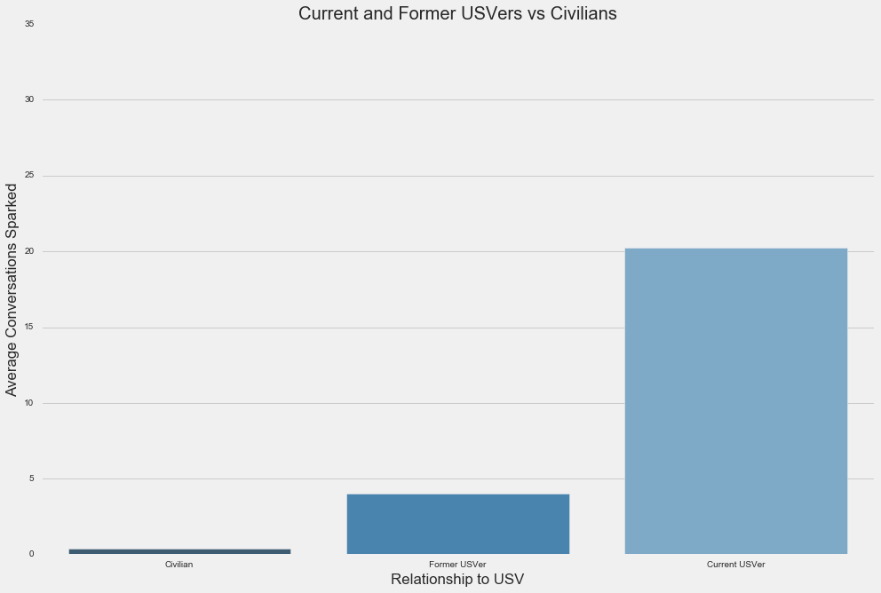

```python
sns.barplot('relation_to_USV','conversations_sparked',data=posters, palette="Blues_d",estimator=np.mean,ci=None)
sns.plt.title("Current and Former USVers vs Civilians")
sns.axlabel("Relationship to USV","Average Conversations Sparked")
plt.ylim(0,35)
sns.plt.savefig("USVers vs Non-USVers (Top Posts).png", dpi=100)
```

Current USVers tend to spark more conversations. Could that be because the civilian category is weighed down by inactive accounts?

Here is amount of current USVers, former USVers and Civilains who have posted.

```python
posters.groupby('relation_to_USV').count()[['poster']].rename(columns={'poster':'Number of Unique Posters'})
```

| relation_to_USV | Number of Unique Posters |
| --- | --- |
| Civilian | 699 |
| Current USVer | 9 |
| Former USVer | 6 |

There are a lot more Civialians. Perhaps, it's not surpising that their average was low. Below is the same plot, except it gets the maxium conversations sparked, instead of the average for each group.

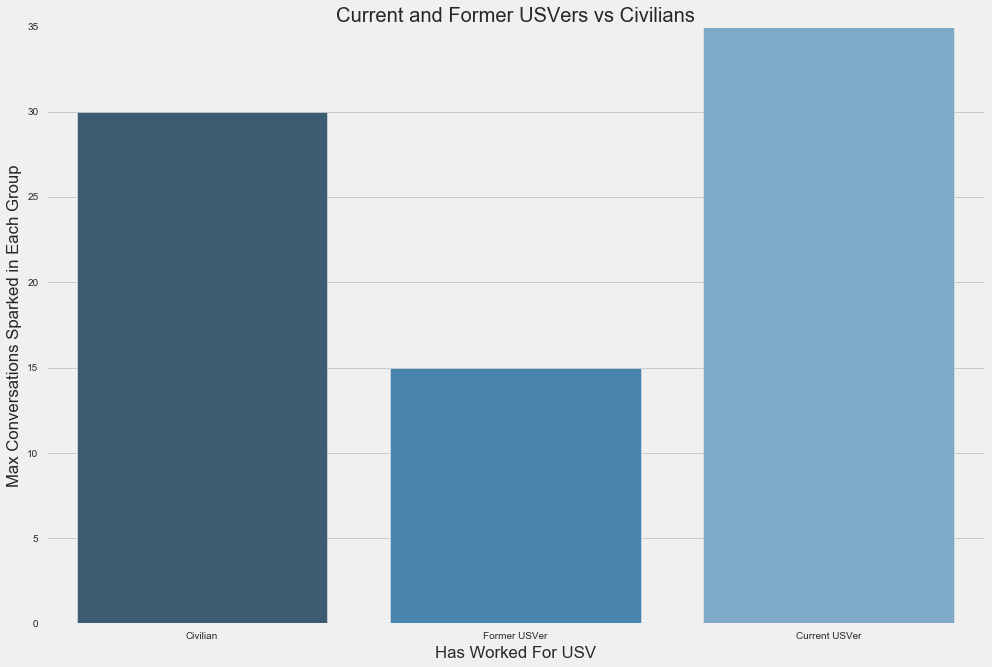

```python
sns.barplot('relation_to_USV','conversations_sparked',data=posters, palette="Blues_d",estimator=np.max,ci=None)
sns.plt.title("Current and Former USVers vs Civilians")
sns.axlabel("Has Worked For USV","Max Conversations Sparked in Each Group")
plt.ylim(0,35)
sns.plt.savefig("USVers vs Non-USVers (Top Posts).png", dpi=100)
```

As you can see, some Civilians (or at least one) have sparked a comparable number of discussions to the USVers. The average USVers does spark more conversations than the average civilian. However, the most active civilians are comparable to USVers.

## Post Patterns

### Post Enagagement by Time Posted

Does it matter what time of day a post is made?

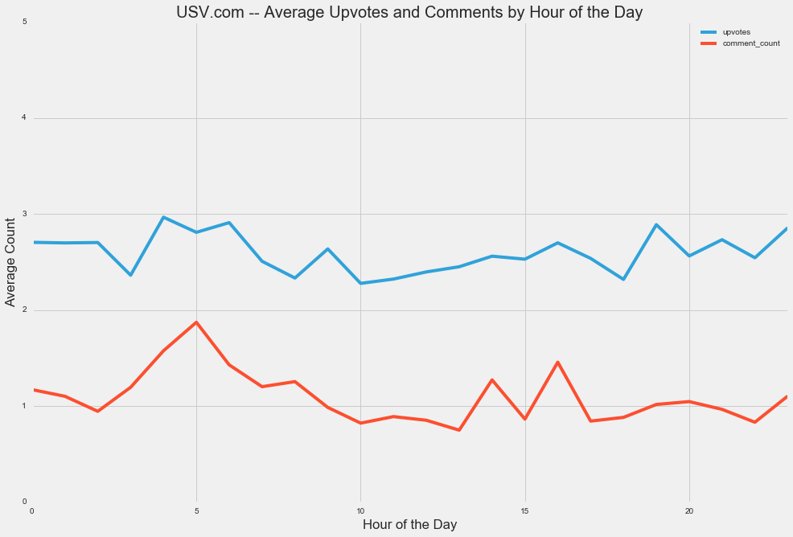

```python
posts.groupby(posts.date_created.dt.hour).mean()[['upvotes','comment_count']].plot(legend=True)
plt.ylim(0,5)
plt.title('USV.com -- Average Upvotes and Comments by Hour of the Day')
plt.xlabel('Hour of the Day')
plt.ylabel('Average Count')
```

There is not a strong pattern between when something is posted and the number of upvotes and comments it recieves.

This is what the same graph looks like for Product Hunt (data pulled from their API):

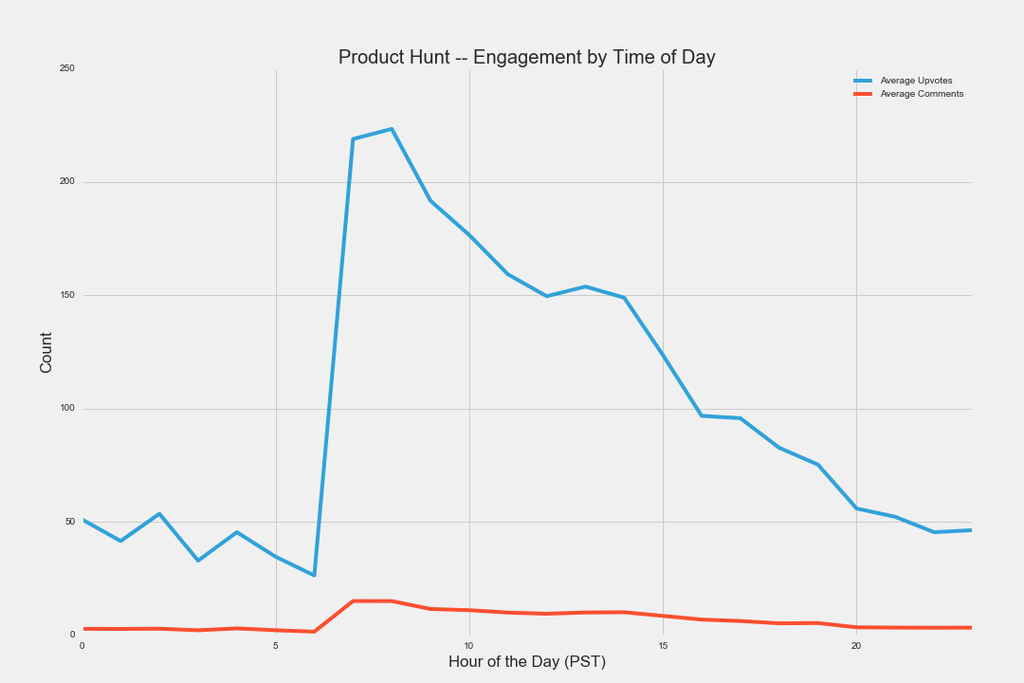

```python
Image(filename='images/Counts-and-Upvotes-by-Hour-Product-Hunt.png')
```

Product Hunt has s strong pattern based on time of day. This is because Product Hunt resets every day. USV.com does not.

This could indicate an opportunity. If USV.com built in a predictable time cycle for new posts, it could lead to habitual visits, posts and discussions. Reddit and Hacker News show you don't need a daily leaderboard that restart at midnight. However, people should expect to see new content at some time interval. AVC does this very well.

```python
##
# posts.set_index('date_created')['comment_count'].resample('M').count()[:-1].plot()
# That is the evolution of montly posts over time. USV.com was primarly a blog for occasional
# posts from 2006 - 2013. You can see when USV.com allowed anyone to submit links. By number of
# posts, this peaked in 2013. However, I think number of posts is the wrong metric.
```

### Posts The Community Likes To Discuss

First, we must define "likes to discuss". One way to define it is by number of comments. Here is the distribution of posts by the number of comments recieved:

```
Comment Count Skew: 24.05
```

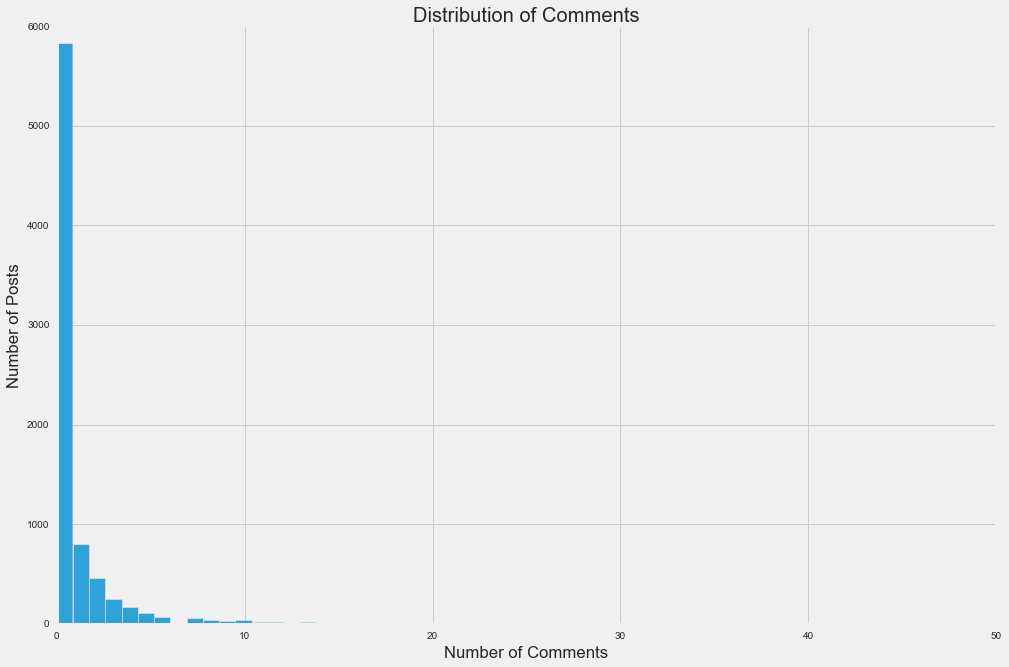

```python
posts.comment_count.loc[posts.comment_count>=0].hist(bins=250)
plt.xlabel('Number of Comments')
plt.ylabel('Number of Posts')
plt.title('Distribution of Comments')
plt.savefig('Distribution of Comments.png')
plt.xlim(0,50)
print "Comment Count Skew: " + str(posts.comment_count.skew().round(2))
```

As can be seen above, most posts get 0 or very few comments. The skew is very postive (23+). Let's define a popular post as one that sparks a discussion by getting at least 5 comments.

```python
# posts.comment_count.value_counts(normalize=True).round(4).sort_index()*100
# That is the distribution of comments. As you can see, 73% of posts got no comments. 90% got 3 or fewer comments.
```

```python
top5_cutoff = posts.comment_count.quantile(.95)
# print "The top 5%% of posts got at least %s comments so that will be the cutoff." %int(top5_cutoff)
```

```python
posts['sparked_conversation'] = posts.comment_count>top5_cutoff
posts['got_comments'] = posts.comment_count>0
```

```python
posts[['title','body_text']] = posts[['title','body_text']].fillna('')
```

**Optional Explanation of Math**

Now, I will use the TF-IDF* weighting of one and two word phrases that appear in at least 20 posts titles. TF-IDF, is just the word counts in each title relative to how rare the words are across all titles.

```python
vec = CountVectorizer(ngram_range=(1,2),min_df=20,stop_words='english')
X_words = vec.fit_transform(posts.title)
```

```python
transformer = TfidfTransformer()
tfidf = transformer.fit_transform(X_words)
```

Note that data set is small (relative to the number of features), which makes it hard to do proper cross validation. Instead, I am using regularization and requiring that a phrase appears 20+ times to reduce overfitting. Even so, I wouldn't try to make predictions with this model.

```python
y = posts.sparked_conversation
model = LogisticRegression(penalty='l2')
model.fit(tfidf,y)
print
```

```python
vocab = zip(vec.get_feature_names(),
            model.coef_[0])

df_vocab = pd.DataFrame(vocab)
```

**Popular Title Words**

The higher the coef, the more likely a word is to spark a conversation. Here are the top 20 words:

```python
df_vocab.columns = ['word','coef']
df_vocab.sort_values('coef',ascending=False).head(20)
```

|  | word | coef |
| --- | --- | --- |
| 315 | usv | 2.772766 |
| 147 | introducing | 1.483714 |
| 20 | ask usv | 1.309939 |
| 264 | self | 1.247119 |
| 43 | car | 1.203155 |
| 53 | code | 1.181710 |
| 89 | economy | 1.093197 |
| 275 | snapchat | 1.079421 |
| 168 | let | 1.054378 |
| 80 | did | 1.043933 |
| 306 | trust | 1.012399 |
| 216 | open | 0.995027 |
| 328 | vs | 0.971555 |
| 44 | case | 0.968341 |
| 30 | bitcoin | 0.965480 |
| 64 | crowdfunding | 0.961925 |
| 270 | silicon | 0.959581 |
| 163 | lead | 0.949660 |
| 82 | disruption | 0.930395 |
| 92 | employees | 0.894577 |

### Topics on USV.com

Above we looked at the titles. Now, let's check out the post description. By using [non-negative matrix factorization](https://en.wikipedia.org/wiki/Non-negative_matrix_factorization), I tried to pull out topics.

The post descriptions have too few words for perfectly reliable topic models. Many topics were sensitive to hyperparamters. Even with all of the noise, there were still some topics that stood out.

Below are some topics and their top 10 words. I did not use tags to find these. This came solely from which words appear together in descriptions.

```python
posts['body_text_raw'] = posts.body_text
posts['body_text_clean'] = posts.body_text.str.replace(r'\[a-z][a-z][1-9]\[a-z][a-z][a-z]', '', case=False)
posts['body_text_clean'] = posts.body_text_clean.str.replace('\'', '', case=False)
posts['body_text_clean'] = posts.body_text_clean.str.replace('[a-z]/[a-z]', '', case=False)
```

```python
custom_stopwords= ['looks','look','read','great','good','dont','really','done','kik','lets',
           'http','let','just','that','thats','like','lot','interesting','think','im',
           'thought','thoughts','id','love','twitter']

my_stop_words = text.ENGLISH_STOP_WORDS.union(custom_stopwords)
```

```python
# This step performs the vectorization,
# tf-idf, stop word extraction, and normalization.
# It assumes docs is a Python list,
#with reviews as its elements.
cv = TfidfVectorizer(ngram_range=[1,1],max_df=0.6, min_df=4,stop_words=my_stop_words)
doc_term_matrix = cv.fit_transform(posts.body_text_clean)

# The tokens can be extracted as:
vocab = cv.get_feature_names()
```

```python
#trial and error got me to 45
num_topics = 45
#doctopic is the W matrix
decomp = decomposition.NMF(n_components = num_topics, random_state=50,init = 'nndsvda')
doctopic = decomp.fit_transform(doc_term_matrix)
```

```python
n_top_words = 10
topic_words = []
for topic in decomp.components_:
    idx = np.argsort(topic)[::-1][0:n_top_words]
    topic_words.append([vocab[i] for i in idx])
```

```python
topic_names = [
    "Web Services", "Bitcoin and Blockchain","AVC or Continuations","Customer Success",
    "Mobile","USV Community","Startup Ecosystems","Data Privacy and Security",0,"Net Neutrality",1,"Long Read",2,
    "Venture Capital",3,"Tech Job Market","HTML Tags","Internt Access",4,"Markets","Test Post",
    "Big 4 Tech Co's","Linux & Cloud","Business Models","App Store",5,6,7,8,9,10,11,"iOS vs Android",12,
    "AVC Posts",13,14,"Community Feedback","Technology and Patents","Video","Startup Building",15,
    "Open Source","Product Development",16
              ]
```

```python
#outputs all named topics and its top 10 words
for count,i in enumerate(topic_words):
    if isinstance(topic_names[count],int):
        pass
    else:
        print "Topic: %s"%topic_names[count]
        print "Top words: " + ", ".join(i)
        print
```

```
Topic: Web Services
Top words: web, services, service, users, social, network, information, networks, content, media

Topic: Bitcoin and Blockchain
Top words: bitcoin, currency, blockchain, exchange, coinbase, money, mining, transactions, digital, value

Topic: AVC or Continuations
Top words: post, blog, alberts, freds, wrote, rand, comments, founder, earlier, news

Topic: Customer Success
Top words: customer, success, customers, gainsight, management, service, important, marketing, satisfaction, successful

Topic: Mobile
Top words: mobile, app, design, facebook, future, device, experience, devices, market, messaging

Topic: USV Community
Top words: usv, com, posting, cross, www, avc, mikecollett, fred, list, team

Topic: Startup Ecosystems
Top words: startup, ecosystem, build, life, hear, story, mistakes, founders, key, thinking

Topic: Data Privacy and Security
Top words: data, privacy, users, security, science, market, messenger, point, visualization, using

Topic: Net Neutrality
Top words: net, neutrality, fight, fcc, different, case, piece, marc, thing, end

Topic: Long Read
Top words: nice, essay, analysis, interview, kickstarter, amazon, piece, transparency, equity, write

Topic: Venture Capital
Top words: startups, invest, vcs, investors, advice, growth, businesses, founders, money, point

Topic: Tech Job Market
Top words: tech, job, nyc, women, culture, future, talks, innovation, ny, chicago

Topic: HTML Tags
Top words: div, class, story, review, section, media, social, gives, footer, image

Topic: Internt Access
```

[output cut: 28 more lines]

```

Topic: Technology and Patents
Top words: technology, software, innovation, patent, patents, piece, disruptive, peer, impact, education

Topic: Video
Top words: video, content, interview, marketing, media, watch, music, youtube, week, creators

Topic: Startup Building
Top words: companies, capital, investors, venture, market, vc, investment, angel, investing, funding

Topic: Open Source
Top words: open, source, software, project, platform, foundation, yes, code, projects, networking

Topic: Product Development
Top words: product, building, products, amazing, hunt, team, design, important, growth, user
```

```python
posts['clean_upvotes']= posts.voted_users.str.replace('^u|\'|\[|\]','')
users_votes = posts.clean_upvotes.str.get_dummies(",")
```

```python
users_votes.columns = users_votes.columns.to_series().str.replace('^u','')
```

```python
posts = pd.concat([posts,users_votes],axis=1)
```

```python
model = LogisticRegression(penalty='l2')
y = posts.sparked_conversation
model.fit(doctopic,y)
print
```

This is how well a topic predicts if the community will discuss it. This is grossly simplifying. Topic popularity should changes over time. Different user segments probably have different preferences. Even so, it's quite interesting.

```python
community_topics = pd.DataFrame([pd.Series(topic_names),model.coef_[0]]).T.sort_values(1,ascending=False)
community_topics.columns=["Topic","Coefficent"]
community_topics[community_topics.Topic.map(lambda x: type(x))!=float]
```

|  | Topic | Coefficent |
| --- | --- | --- |
| 5 | USV Community | 2.79843 |
| 1 | Bitcoin and Blockchain | 2.09516 |
| 2 | AVC or Continuations | 2.0201 |
| 37 | Community Feedback | 1.0116 |
| 24 | App Store | 0.85171 |
| 4 | Mobile | 0.708065 |
| 17 | Internt Access | 0.5402 |
| 34 | AVC Posts | 0.470501 |
| 0 | Web Services | 0.452506 |
| 38 | Technology and Patents | 0.353975 |
| 43 | Product Development | 0.262379 |
| 42 | Open Source | 0.197744 |
| 21 | Big 4 Tech Co's | 0.191889 |
| 40 | Startup Building | 0.134794 |
| 39 | Video | 0.115053 |
| 13 | Venture Capital | 0.0783075 |
| 9 | Net Neutrality | 0.0504006 |
| 6 | Startup Ecosystems | 0.0124453 |
| 23 | Business Models | -0.121243 |
| 11 | Long Read | -0.123889 |
| 19 | Markets | -0.135989 |
| 32 | iOS vs Android | -0.159303 |
| 20 | Test Post | -0.198601 |
| 15 | Tech Job Market | -0.270777 |
| 7 | Data Privacy and Security | -0.282444 |
| 16 | HTML Tags | -0.289521 |
| 3 | Customer Success | -0.339316 |
| 22 | Linux & Cloud | -0.600329 |

### Finding Posts on a Topic

We can use these topic models to find posts on a topic. For example, "Bitcoin and Blockchain" is a clear topic. These are the "most Bitcoin" posts. These posts are sorted by how strongly it's description is associated the Bitcoin Topic. This could be used for a recommendation engine. However, not all topics came through as cleanly as Bitcoin.

```python
doctopic_df = pd.DataFrame(doctopic)
doctopic_df.columns = topic_names
posts_topics = pd.concat([posts,doctopic_df],axis=1)
```

```python
topic = "Bitcoin and Blockchain"
posts_topics.sort_values( topic,ascending=False)[['poster','title',"body_text",topic]].head(20)
```

|  | poster | title | body_text | Bitcoin and Blockchain |
| --- | --- | --- | --- | --- |
| 3683 | TomLabus | Nakamoto Bitcoin Defense | In Bitcoin | 0.531392 |
| 4210 | pointsnfigures | Burger King to Add Mobile Payments on Cell Phones | precursor to Bitcoin Burgers? | 0.531392 |
| 2889 | fredwilson | A VC: Bitcoin - Getting Past Store Of Value an... | Some thoughts on where we go next with bitcoin | 0.531392 |
| 1723 | kidmercury | Bitcoin From Over $900 to Under $540 in Less t... | #bitcoin #hft | 0.531392 |
| 5349 | kidmercury | Bots were responsible for bitcoin’s stratosphe... | The problems of bitcoin anarchy | 0.338237 |
| 7762 | kidmercury | Why Bitcoin Matters (Mini-Documentary) | a good dose of bitcoin propaganda is just what... | 0.331816 |
| 4579 | wmougayar | Search Engine DuckDuckGo Integrates Bitcoin Pr... | DDG goes Bitcoin | 0.329520 |
| 248 | fredwilson | Coinbase | We have been thinking about and looking to mak... | 0.309345 |
| 5532 | N_Clemmons | Coinsis: Bitcoin Credit card [DEMO VIDEO] | Send Bitcoin by email\nPay with a bitcoin cred... | 0.299673 |
| 1303 | wmougayar | You can now buy a car with Bitcoin in Australia | 2 weeks ago, it was "you can buy a beer in Ams... | 0.296406 |
| 7321 | albertwenger | BitQuest - The first minecraft server with bit... | Interesting use case for Bitcoin | 0.293877 |
| 6733 | pointsnfigures | If You Use Facebook, Yelp, Reddit, You Should ... | interesting thought about how to use bitcoin b... | 0.289755 |
| 4937 | fredwilson | The Pied Piper Effect – AVC | Some thoughts on MIT and Bitcoin | 0.287514 |
| 1477 | aweissman | Twitter / marcprecipice: Corner bodega, Brookl... | 10% off if you pay with Bitcoin | 0.285954 |
| 3385 | pointsnfigures | Bitcoin: Store of Value? | is bitcoin a store of value? | 0.283853 |
| 5975 | EllieAsksWhy | Just a Little Bit More Bitcoin Trouble | There has been so much tumult in the bitcoin a... | 0.278721 |
| 4836 | christinacaci | Why in Satoshi's name would you want a bitcoin? | It seemed bitcoin could stand to be a little m... | 0.278001 |
| 5215 | wmougayar | What Block Chain Analysis Tells Us About Bitcoin | Includes some interesting graphs on bitcoin de... | 0.274111 |
| 3563 | pointsnfigures | Good Sign For Future of Bitcoin | 10% of all porn paid for with Bitcoin. | 0.272462 |
| 1345 | nickgrossman | DarkWallet Aims To Be The Anarchist's Bitcoin ... | DarkWallet is an effort to further anonymize b... | 0.269487 |

## Poster Profiles

Here I use the title and topics to predict if a poster will upvote or share something.

That creates a profile of topics and title words a poster likely finds interesting.

Here are some examples:

```python
# Remake the tfidf word matrix with a threshold of 10 instead of 20 counts.
vec_user_profiles = TfidfVectorizer(ngram_range=(1,1),min_df=10,stop_words='english')
X_words = vec_user_profiles.fit_transform(posts.title)
```

```python
def get_user_profile(user):
    model_topics = LogisticRegression(penalty='l2')
    y = users_votes[user]
    model_topics.fit(doctopic,y)

    vocab_topics = zip(topic_names,model_topics.coef_[0])
    df_vocab_topics = pd.DataFrame(vocab_topics)
    df_vocab_topics.columns = ['topic','coef']
    df_vocab_topics = df_vocab_topics[(df_vocab_topics.coef>0)&
                                      (df_vocab_topics.topic.map(lambda x: type(x))!=int)]

    model_words = LogisticRegression(penalty='l2')
    y = users_votes[user]
    model_words.fit(X_words,y)

    vocab = zip(vec_user_profiles.get_feature_names(),model_words.coef_[0])

    df_vocab = pd.DataFrame(vocab)
    df_vocab.columns = ['word','coef']
    df_vocab = df_vocab[df_vocab.coef>0]

    print user
    print
    print "Favorite Topics: " +\
    ", ".join(df_vocab_topics.sort_values('coef',ascending=False).head(10)['topic'])
    print
    print "Favorite Words: " +\
    ", ".join(df_vocab.sort_values('coef',ascending=False).head(25)['word'])
    return None
```

```python
get_user_profile('nickgrossman')
```

```
nickgrossman

Favorite Topics: Net Neutrality, Internt Access, Data Privacy and Security, USV Community, AVC Posts, Video, Test Post, Open Source, HTML Tags, Markets

Favorite Words: nytimes, comcast, fcc, techdirt, hunch, ignore, test, grossman, neutrality, nick, slow, internet, obama, privacy, anti, washington, health, verizon, surveillance, cities, uber, free, snowden, trust, policy
```

```python
get_user_profile('albertwenger')
```

```
albertwenger

Favorite Topics: Open Source, Web Services, Technology and Patents, Startup Building, Internt Access, Net Neutrality, AVC Posts, Data Privacy and Security, AVC or Continuations, Mobile

Favorite Words: continuations, hiring, foursquare, com, wired, update, human, medium, wattpad, revolution, longer, hunt, org, brand, income, computer, age, 500, network, analysis, notes, mit, marketplaces, news, platform
```

```python
get_user_profile('BenedictEvans')
```

```
BenedictEvans

Favorite Topics: Markets, Mobile, Internt Access, Tech Job Market, Product Development, Big 4 Tech Co's

Favorite Words: android, benedict, price, really, mobile, twitter, instagram, self, iphone, youtube, use, scale, evans, dead, facebook, foundation, value, technology, networks, does, platform, social, google
```

```python
get_user_profile('fredwilson')
```

```
fredwilson

Favorite Topics: AVC or Continuations, AVC Posts, USV Community, Startup Building, Bitcoin and Blockchain, iOS vs Android, Long Read, Web Services, Business Models, Net Neutrality

Favorite Words: avc, vc, cliche, techcrunch, panel, continuations, coinbase, week, kik, kickstarter, wsj, talk, friday, blog, albert, evans, twitter, benedict, foursquare, looking, thoughts, capitalism, sessions, atlantic, duckduckgo
```

```python
get_user_profile('aweissman')
```

```
aweissman

Favorite Topics: Long Read, Data Privacy and Security, App Store, Big 4 Tech Co's, Open Source, Internt Access, Startup Building, Mobile, USV Community

Favorite Words: music, yorker, medium, youtube, blog, angellist, com, peer, banks, app, evans, circle, ben, fiber, code, life, indie, funding, ve, beat, billion, bloomberg, free, economist, watch
```

```python
get_user_profile('jmonegro')
print
print "The words worked much better than the topics for Joel"
```

```
jmonegro

Favorite Topics:

Favorite Words: decentralized, blockchain, plan, distributed, wireless, communication, secure, messaging, based, market, 000, paypal, firm, paid, devices, bitcoin, post, stock, hard, email, change, sharing, trends, time, washington

The words worked much better than the topics for Joel
```

```python
get_user_profile('pointsnfigures')
```

```
pointsnfigures

Favorite Topics: Bitcoin and Blockchain, Tech Job Market, Startup Ecosystems, Venture Capital

Favorite Words: chicago, drones, entrepreneurship, tech, good, bitcoin, football, women, robots, corporate, trading, robot, life, competition, federal, old, big, drone, act, make, invest, angel, social, times, wrong
```

```python
get_user_profile('kidmercury')
```

```
kidmercury

Favorite Topics: Bitcoin and Blockchain, Big 4 Tech Co's, Technology and Patents, Internt Access, Community Feedback, Net Neutrality, Video, Markets, Data Privacy and Security, Mobile

Favorite Words: verge, hedge, techcrunch, com, news, amazon, zero, insider, state, bitcoin, technology, disruptive, nsa, currency, code, bank, man, google, says, computers, wants, samsung, china, bloomberg, wsj
```